# Titanic

```r
library('ggplot2') # visualization
library('ggthemes') # visualization
library('scales') # visualization
library('dplyr') # data manipulation
library('mice') # imputation
library('randomForest') # classification algorithm
```

```r
train  <- read.csv('train.csv', stringsAsFactors = F)
test <- read.csv('test.csv', stringsAsFactors = F)
full <- bind_rows(train,test)
# checek the data
str(full)
```

```
'data.frame':   1309 obs. of  12 variables:
 $ PassengerId: int  1 2 3 4 5 6 7 8 9 10 ...
 $ Survived   : int  0 1 1 1 0 0 0 0 1 1 ...
 $ Pclass     : int  3 1 3 1 3 3 1 3 3 2 ...
 $ Name       : chr  "Braund, Mr. Owen Harris" "Cumings, Mrs. John Bradley (Florence Briggs Thayer)" "Heikkinen, Miss. Laina" "Futrelle, Mrs. Jacques Heath (Lily May Peel)" ...
 $ Sex        : chr  "male" "female" "female" "female" ...
 $ Age        : num  22 38 26 35 35 NA 54 2 27 14 ...
 $ SibSp      : int  1 1 0 1 0 0 0 3 0 1 ...
 $ Parch      : int  0 0 0 0 0 0 0 1 2 0 ...
 $ Ticket     : chr  "A/5 21171" "PC 17599" "STON/O2. 3101282" "113803" ...
 $ Fare       : num  7.25 71.28 7.92 53.1 8.05 ...
 $ Cabin      : chr  "" "C85" "" "C123" ...
 $ Embarked   : chr  "S" "C" "S" "S" ...
```

```r
full$Title <- gsub('(.*, )|(\\..*)', '',full$Name   )
```

’(\..*)select string after a DOT. DOT means any charcater* occuring 0 or more times. (.*, )select string precedes a Comma. So that selects “Cumings, .John Bradley” from the original string. Another gsub(“^.*, (.*)\..*$“,”\1“, names) where (.*) denotes the Term that you want to preserve in our exmaple its Mr’

```r
# show Title count by sex
table(full$Title, full$Sex)
```

```
               female male
  Capt              0    1
  Col               0    4
  Don               0    1
  Dona              1    0
  Dr                1    7
  Jonkheer          0    1
  Lady              1    0
  Major             0    2
  Master            0   61
  Miss            260    0
  Mlle              2    0
  Mme               1    0
  Mr                0  757
  Mrs             197    0
  Ms                2    0
  Rev               0    8
  Sir               0    1
  the Countess      1    0
```

```r
rare_title <- c('Dona', 'Lady', 'the Countess','Capt', 'Col', 'Don','Dr', 'Major', 'Rev', 'Sir', 'Jonkheer')
# Also reassign mlle, ms, and mme accordingly
full$Title[full$Title=='Mlle'] <- 'Miss'
full$Title[full$Title == 'Ms']          <- 'Miss'
full$Title[full$Title == 'Mme']         <- 'Mrs'
full$Title[full$Title %in% rare_title ] <- 'Rare Title'
# Show title counts by sex again
table(full$Sex, full$Title)
```

```
         Master Miss  Mr Mrs Rare Title
  female      0  264   0 198          4
  male       61    0 757   0         25
```

```r
# Finally, grab surname from passenger name
full$Surname <- sapply(full$Name,
                       function(x) strsplit(x, split ='[,]')[[1]][1])
nlevels(factor(full$Surname))
```

```
[1] 875
```

```r
#'It can be done as gsub("(,.*)","",full$Name).Split on COMMA. factor is used for categorical data. here nlevels is counting the total surnames'
```

```r
# Create a family size variable including the passenger themselves
full$Fsize <- full$SibSp +full$Parch +1
full$Family <- paste(full$Surname, full$Fsize, sep = '-' )
head(full$Family)
```

```
[1] "Braund-2"    "Cumings-2"   "Heikkinen-1" "Futrelle-2"  "Allen-1"     "Moran-1"
```

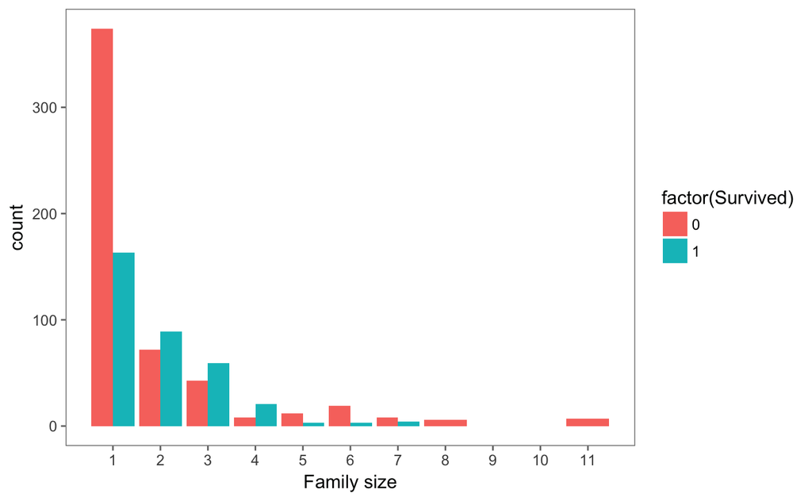

```r
ggplot(full[1:891,], aes(x= Fsize, fill = factor(Survived)))+
  geom_bar(stat = 'count', position = 'dodge')+
  scale_x_continuous(breaks = c(1:20))+
  labs(x='Family size')+
  theme_few()
```

```r
##891 are the total training data
```

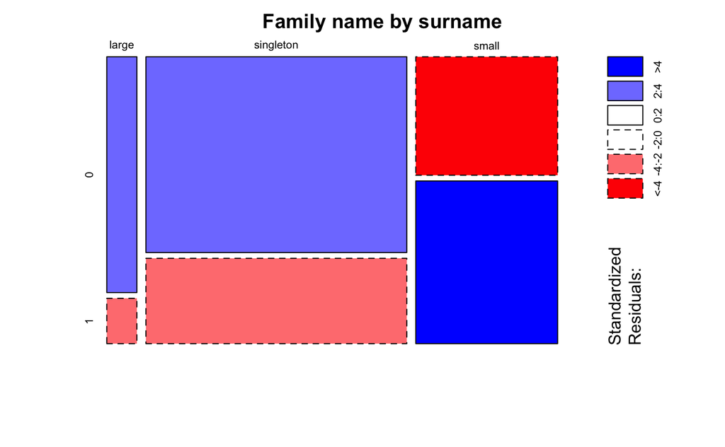

```r
full$FsizeD[full$Fsize==1] <-'singleton'
full$FsizeD[full$Fsize <5 & full$Fsize >1] <- 'small'
full$FsizeD[full$Fsize > 4] <- 'large'
# Show family size by survival using a mosaic plot
mosaicplot(table(full$FsizeD, full$Survived), main= 'Family name by surname', shade = TRUE)
```

```r
#Let's enquire about the Passengers' CABIN
strsplit(full$Cabin[2], NULL)[[1]]
```

```
[1] "C" "8" "5"
```

```r
# Create a Deck variable. Get passenger deck A - F:
full$Deck <- factor(sapply(full$Cabin, function(x) strsplit(x, NULL)[[1]][1]))
```

**Sensible value imputation**

```r
full$Embarked[full$Embarked == ""] <- NA

full[(which(is.na(full$Embarked))), 1]
```

```r
# Value of Embarked column in row 63 and 830 is NULL
full[c(62, 830),"Embarked"]
```

[output not shown]

```r
full[c(62, 830), 'Fare'][[1]][1]
```

```
[1] 80
```

```r
full[c(62, 830), 'Fare'][[1]][1]
```

```
[1] 80
```

Both passengers had first class tickets that they spent 80 (pounds?) on. Let’s see the embarkment ports of others who bought similar kinds of tickets.

```r
full %>%
  group_by(Embarked, Pclass) %>%
  filter(Pclass == "1") %>%
  summarise(mfare = median(Fare),
            n = n())
```

| Embarked | Pclass | mfare | n |
| --- | --- | --- | --- |
| C | 1 | 78.2667 | 143 |
| Q | 1 | 90.0000 | 3 |
| S | 1 | 52.0000 | 177 |

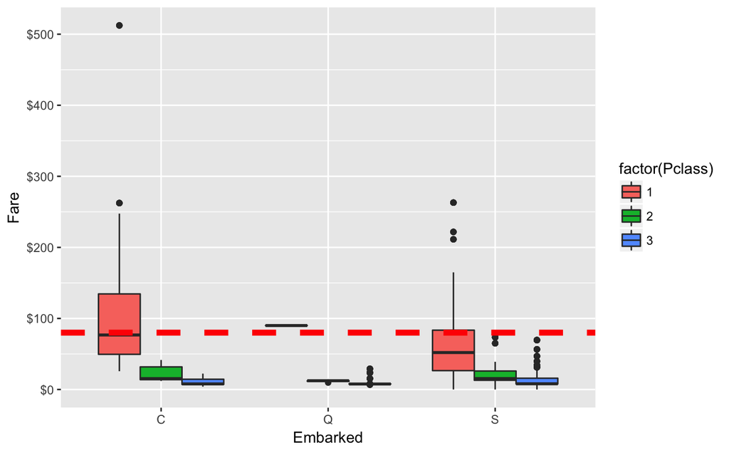

```r
# Get rid of our missing passenger IDs
embark_fare <- full %>%
  filter(PassengerId != 62 & PassengerId != 830)
# Use ggplot2 to visualize embarkment, passenger class, & median fare
ggplot(embark_fare, aes(x= Embarked, y= Fare, fill=factor(Pclass)))+
  geom_boxplot()+
  geom_hline(aes(yintercept=80),
             color ='red',linetype='dashed', lwd=2) +
  scale_y_continuous(labels=dollar_format())
```

Voilà! The median fare for a first class passenger departing from Charbourg (‘C’) coincides nicely with the $80 paid by our embarkment-deficient passengers. I think we can safely replace the NA values with ‘C’.

```r
# Since their fare was $80 for 1st class, they most likely embarked from 'C'
full$Embarked[c(62,830)] <- 'C'
```

We’re close to fixing the handful of NA values here and there. Passenger on row 1044 has an NA Fare value.

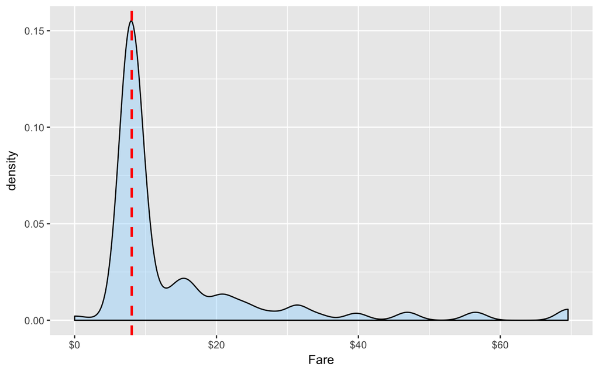

```r
ggplot(full[full$Pclass == '3' & full$Embarked == 'S', ],
  aes(x = Fare)) +
  geom_density(fill = '#99d6ff', alpha=0.4) +
  geom_vline(aes(xintercept=median(Fare, na.rm=T)),
    colour='red', linetype='dashed', lwd=1)+
  scale_x_continuous(labels=dollar_format())
```

From this visualization, it seems quite reasonable to replace the NA Fare value with median for their class and embarkment which is $8.05.

```r
# Replace missing fare value with median fare for class/embarkment
full$Fare[1044] <- median(full[full$Pclass == '3' & full$Embarked == 'S', ]$Fare, na.rm = TRUE)
```

**Predictive imputation**

There are quite a few missing Age values in our data.

```r
sum(is.na(full$Age))
```

```
[1] 263
```

We could definitely use rpart (recursive partitioning for regression) to predict missing ages, but I’m going to use the mice package for this task

```r
# Make variables factors into factors
factor_vars <- c('PassengerId','Pclass','Sex','Embarked',
                 'Title','Surname','Family','FsizeD')
full[factor_vars] <- lapply(full[factor_vars], function(x) as.factor(x))
# Set a random seed
set.seed(129)
# Perform mice imputation, excluding certain less-than-useful variables:
mice_mod <- mice(full[, !names(full) %in% c('PassengerId','Name','Ticket','Cabin','Family','Surname','Survived')], method='rf')
```

```r
mice_output <- complete(mice_mod)
```

Let’s compare the results we get with the original distribution of passenger ages to ensure that nothing has gone completely awry.

[figure not shown]

```r
# Plot age distributions
par(mfrow=c(1,2))
hist(full$Age, freq = F, main='Age: Original Data',
  col='darkgreen', ylim=c(0,0.04))
hist(mice_output$Age, freq=F, main='Age: MICE Output',
  col='lightgreen', ylim=c(0,0.04))
```

Things look good, so let’s replace our age vector in the original data with the output from the mice model.

```r
# Replace Age variable from the mice model.
full$Age <- mice_output$Age
sum(is.na(full$Age))
```

```
[1] 0
```

**Feature Engineering**

Now that we know everyone’s age, we can create a couple of new age-dependent variables: Child and Mother.A child will simply be someone under 18 years of age and a mother is a passenger who is 1) female, 2) is over 18, 3) has more than 0 children (no kidding!), and 4) does not have the title ‘Miss’.

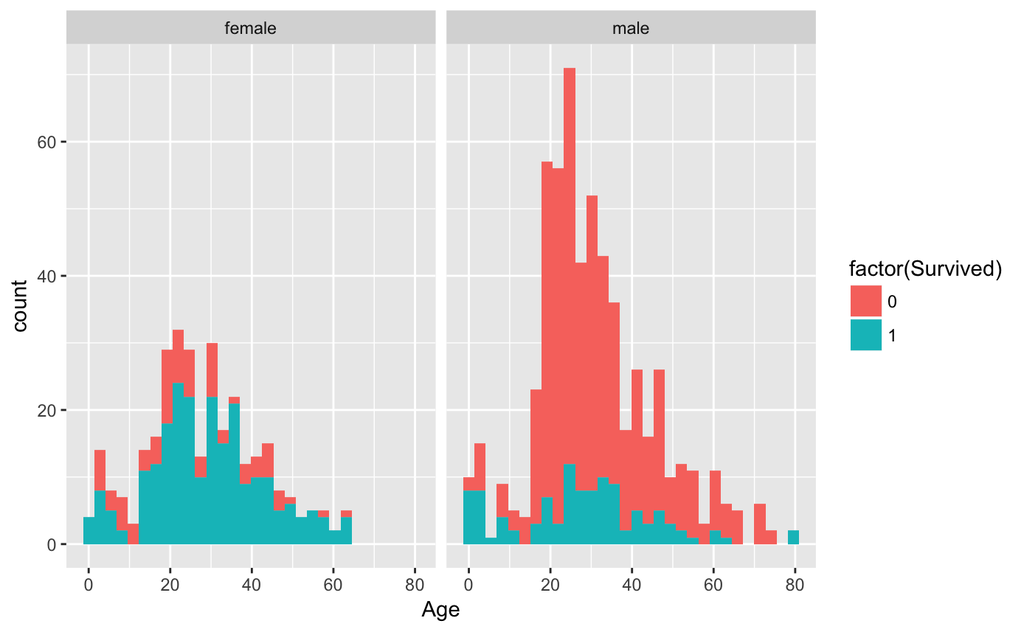

```r
# First we'll look at the relationship between age & survival
ggplot(full[1:891,], aes(Age, fill = factor(Survived)))+
  geom_histogram() +
  facet_grid(.~Sex)
```

```r
# Create the column child, and indicate whether child or adult
full$Child[full$Age<18] <- 'Child'
full$Child[full$Age >= 18] <- 'Adult'
# Show counts
table(full$Child, full$Survived)
```

```
          0   1
  Adult 484 274
  Child  65  68
```

```r
# Adding Mother variable
full$Mother <- 'Not Mother'
full$Mother[full$Sex=='female' & full$Parch >0 & full$Age > 18 & full$Title != 'Miss' ] <- 'Mother'
# Show counts
table(full$Mother, full$Survived)
```

```
               0   1
  Mother      16  39
  Not Mother 533 303
```

```r
full$Child  <- factor(full$Child)
full$Mother <- factor(full$Mother)
```

All of the variables we care about should be taken care of and there should be no missing data. I’m going to double check just to be sure:

```r
md.pattern(full)
```

```
NAs introduced by coercionNAs introduced by coercionNAs introduced by coercion
```

```
    PassengerId Pclass Sex Age SibSp Parch Fare Embarked Title Surname Fsize Family
150           1      1   1   1     1     1    1        1     1       1     1      1
 61           1      1   1   1     1     1    1        1     1       1     1      1
 54           1      1   1   1     1     1    1        1     1       1     1      1
511           1      1   1   1     1     1    1        1     1       1     1      1
 30           1      1   1   1     1     1    1        1     1       1     1      1
235           1      1   1   1     1     1    1        1     1       1     1      1
176           1      1   1   1     1     1    1        1     1       1     1      1
 92           1      1   1   1     1     1    1        1     1       1     1      1
              0      0   0   0     0     0    0        0     0       0     0      0
    FsizeD Child Mother Ticket Survived Deck Name Cabin
150      1     1      1      1        1    1    0     0    2
 61      1     1      1      1        0    1    0     0    3
 54      1     1      1      0        1    1    0     0    3
511      1     1      1      1        1    0    0     0    3
 30      1     1      1      0        0    1    0     0    4
235      1     1      1      1        0    0    0     0    4
176      1     1      1      0        1    0    0     0    4
 92      1     1      1      0        0    0    0     0    5
         0     0      0    352      418 1014 1309  1309 4402
```

We have finally finished treating all of the relevant missing values in the Titanic dataset which has included some fancy imputation with mice.

```r
# Split the data back into a train set and a test set
train <- full[1:891,]
test <- full[892:1309,]
```

**Building the model**

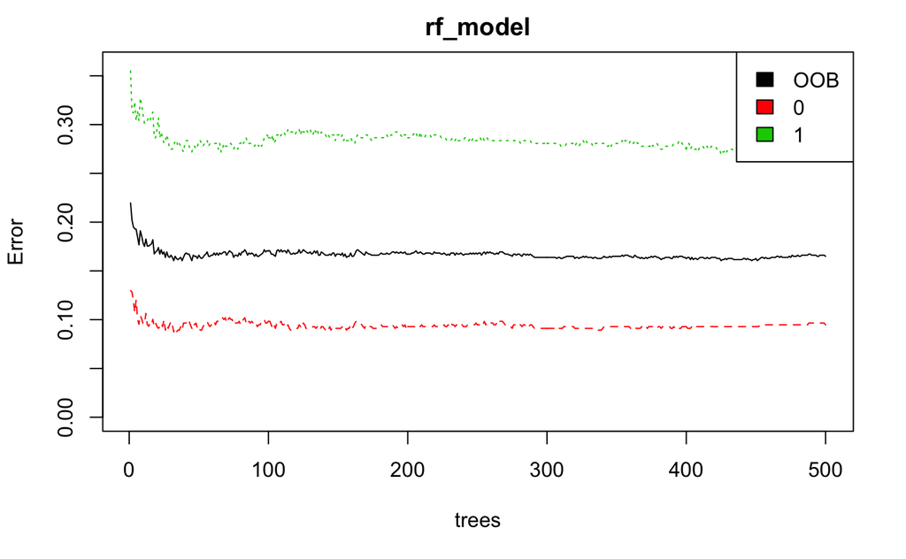

```r
# Set a random seed
set.seed(754)
# Build the model (note: not all possible variables are used)
rf_model <- randomForest(factor(Survived) ~ Pclass + Sex + Age + SibSp + Parch +
                                            Fare + Embarked + Title +
                                            FsizeD + Child + Mother,
                                            data = train)
# Show model error
plot(rf_model, ylim=c(0,0.36))
legend('topright', colnames(rf_model$err.rate), col=1:3, fill=1:3)
```

The black line shows the overall error rate which falls below 20%. The red and green lines show the error rate for ‘died’ and ‘survived’ respectively. We can see that right now we’re much more successful predicting death than we are survival.

**Variable importance** Relative variable importance by plotting the Mean decrease in “Gini” calculated across all trees.

```r
# Get importance
importance    <- importance(rf_model)
varImportance <- data.frame(Variables = row.names(importance),
                            Importance = round(importance[ ,'MeanDecreaseGini'],2))
varImportance
```

|  | Variables | Importance |
| --- | --- | --- |
| Pclass | Pclass | 30.05 |
| Sex | Sex | 59.34 |
| Age | Age | 47.77 |
| SibSp | SibSp | 12.53 |
| Parch | Parch | 8.03 |
| Fare | Fare | 59.07 |
| Embarked | Embarked | 9.73 |
| Title | Title | 65.90 |
| FsizeD | FsizeD | 17.34 |
| Child | Child | 4.44 |

[output cut: 1 more lines]

```r
# Create a rank variable based on importance
rankImportance <- varImportance %>%
  mutate(Rank=paste0('#', dense_rank(desc(Importance))))
rankImportance
```

| Variables | Importance | Rank |
| --- | --- | --- |
| Pclass | 30.05 | #5 |
| Sex | 59.34 | #2 |
| Age | 47.77 | #4 |
| SibSp | 12.53 | #7 |
| Parch | 8.03 | #9 |
| Fare | 59.07 | #3 |
| Embarked | 9.73 | #8 |
| Title | 65.90 | #1 |
| FsizeD | 17.34 | #6 |
| Child | 4.44 | #10 |

[output cut: 1 more lines]

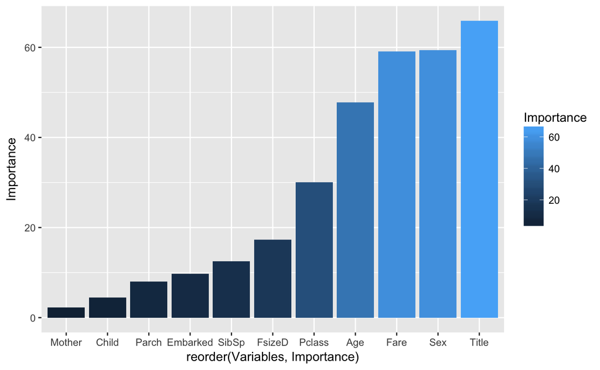

```r
# Use ggplot2 to visualize the relative importance of variables
ggplot(rankImportance, aes(x= reorder(Variables, Importance),
                           y=Importance, fill= Importance))+
  geom_bar(stat='identity')
```

Our title variable! It has the highest relative importance out of all of our predictor variables.

```r
# Predict using the test set
prediction <- predict(rf_model, test)
# Save the solution to a dataframe with two columns: PassengerId and Survived (prediction)
solution <- data.frame(PassengerID= test$PassengerId, Survived= prediction)
head(solution)
```

|  | PassengerID | Survived |
| --- | --- | --- |
| 892 | 892 | 0 |
| 893 | 893 | 0 |
| 894 | 894 | 0 |
| 895 | 895 | 0 |
| 896 | 896 | 1 |
| 897 | 897 | 0 |